# Zielgruppenkompetenzen: PIAAC Bericht

Grundbildungspfade

Nate Breznau

## 0.1 Data

Die Daten stammen aus den ersten beiden Zyklen von PIAAC. Die Dateien zum Importieren und Bereinigen der Daten liegen im Ordner /PIAAC_VET_Basics.

Diese Studie war untestutzt von mein [PIAAC Variable Finder](https://nate-breznau.shinyapps.io/PIAAC_Variable_Finder/) app.

Hinweiss: A2_Q04aDEX “Und wie ist es mit der deutschen Sprache: Responses: 01: Wie gut sprechen Sie Deutsch? | 02: Wie gut schreiben Sie auf Deutsch? | 03: Wie gut lesen Sie auf Deutsch?” ist nicht im PUF (Public Use File)

## 0.2 Deutsch als Zweitsprache, gering Qualifizierter

**GrundBildungsBrücken Hamburg (GBHH)**

Einwanderer mit ISCED 1/2, Deutsch als Zweitsprache.

### 0.2.1 Table 1. Bestimmt Einwanderer Bevölkerungsstatistik

Table 1. Bevölkerungsstatistik, 16 bis 65, Deutschland Zielgruppe: Einwanderer mit ISCED 1/2, Deutsch als Zweitsprache

| Gruppe | Jahr | Einwohnerzahl | Prozent |
| --- | --- | --- | --- |
| ISCED = 3+ | 2022 | 43151356 | 81.1 |
| Eingeborener,Deutsch 1.Sprache, ISCED < 3 | 2022 | 5415117 | 10.2 |
| Einwanderer, Deutsch 2.Sprache, ISCED < 3 | 2022 | 2535486 | 4.8 |
| Other | 2022 | 2084040 | 3.9 |
| ISCED = 3+ | 2012 | 43682159 | 81.4 |
| Eingeborener,Deutsch 1.Sprache, ISCED < 3 | 2012 | 6491569 | 12.1 |
| Einwanderer, Deutsch 2.Sprache, ISCED < 3 | 2012 | 1804981 | 3.4 |
| Other | 2012 | 1678830 | 3.1 |

### 0.2.2 Figure 1. Einwanderern mit Deutsch als Zweitsprache Kompetenzen

Ein Vergleich der Kompetenzen von Einwanderern mit Deutsch als Zweitsprache und gering formaler Bildung (ISCED 1 oder 2, keine oder nur geringe Sekundarschulbildung) zeigt, dass die Rechen- und Lesekompetenz seit 2012 zurückgegangen ist, insbesondere die Lesekompetenz. Während ähnlich gebildete gebürtige Deutsche mit Deutsch als Muttersprache viel höhere Kompetenzen aufweisen und diese seit 2012 im Durchschnitt gestiegen sind - sie liegen nicht so weit hinter denen mit höherer formaler Bildung.

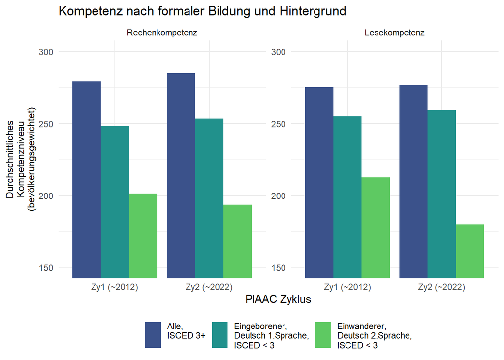

## 0.3 Gering lit. Erwachsene, die i.d. Pflegehilfe eine Ausbildung machen möchten

**Grundbildung in der Pflege stärken (GriPs)**

Nicht genau identifizierbar. Wir können nur Leute die gerade in Bildung oder Weiterbildung sind, und ,Gesundheit’ studieren.

## 0.4 Langzeitarbeitslose, gering lit.

**Berliner Kooperations-verbund Arbeits-orientierte GB (BerKo)**

Bundesrepublik Definition von Langzeitarbeitslos ist 12 Monate.

### 0.4.1 Table 2. Langzeitarbeitslos

Table 2. Bevölkerungsstatistik, 16 bis 65, Deutschland Zielgruppe: Langzeitarbeitslose (mind. 12 mo.)

| Gruppe | Jahr | Einwohnerzahl | Prozent |
| --- | --- | --- | --- |
| Nicht Langzeitarbeitslos | 2022 | 51803856 | 97.4 |
| Langzeitarbeitslos, 12mo+ | 2022 | 1382144 | 2.6 |
| Nicht Langzeitarbeitslos | 2012 | 52302129 | 97.5 |
| Langzeitarbeitslos, 12mo+ | 2012 | 1355411 | 2.5 |

### 0.4.2 Figure 2. Kompetenzverteilung Langzeitarbeitslos

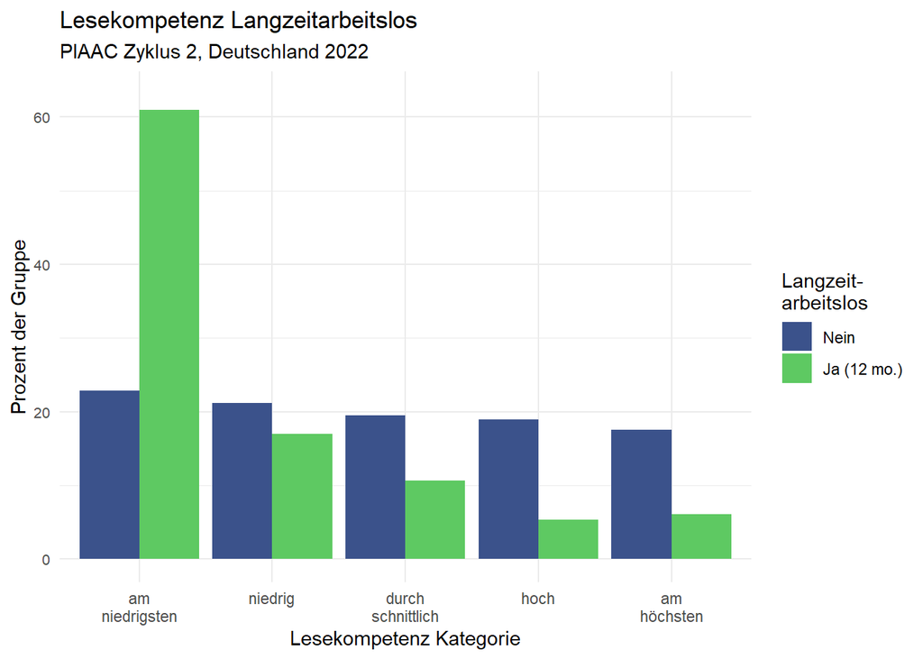

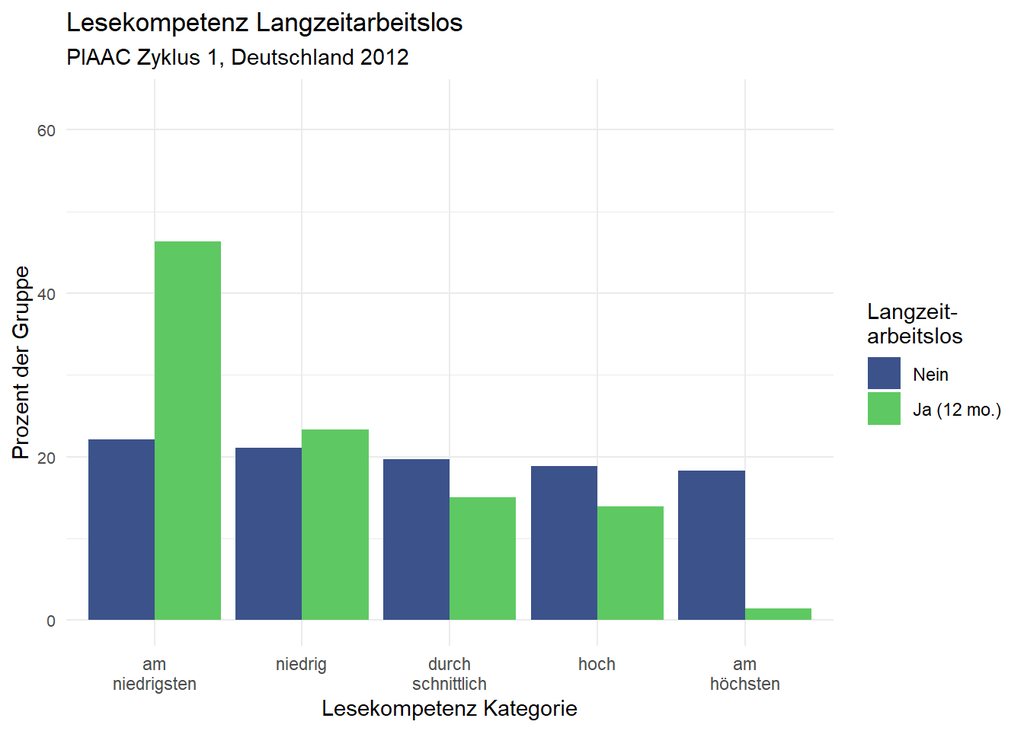

## 0.5 Azubis, gering Literalität

**Berliner Kooperations-verbund Arbeits-orientierte GB (BerKo)**

Diese Gruppe ist nur annähernd. Wir erfassen diejenigen, die ISCED 3 noch nicht abgeschlossen haben. Und dann sind sie entweder 24 Jahre oder jünger und haben den Status „in Arbeit und Ausbildung“ oder den Status „ISCED 3 abgeschlossen oder befindet sich noch in Ausbildung, 16 bis 24 Jahre alt“ und den Status „in Arbeit und Ausbildung“. Dabei fehlen die über 25-Jährigen und schließen wahrscheinlich auch einige ein, die andere Bildungsformen als eine Berufsausbildung anstreben.

### 0.5.1 Table 3. Bevölkerungsstatistik Azubis

Table 3. Bevölkerungsstatistik Auszubildene, 16 bis 65, Deutschland

| Gruppe | Jahr | Einwohnerzahl | Prozent |
| --- | --- | --- | --- |
| Nicht Azubi | 2022 | 44818500 | 84.3 |
| Azubi. | 2022 | 1169427 | 2.2 |
| Other | 2022 | 7198074 | 13.5 |
| Nicht Azubi | 2012 | 44062174 | 82.1 |
| Azubi. | 2012 | 1537485 | 2.9 |
| Other | 2012 | 8057881 | 15.0 |

### 0.5.2 Table 4. Bevölkerungsstatistik Azubis, gering Lit.

Table 4. Bevölkerungsstatistik, 16 bis 65, Deutschland Auszubildene, gering Literalität

| Gruppe | Jahr | Einwohnerzahl | Prozent |
| --- | --- | --- | --- |
| Nicht Azubi., nicht gering Lit. | 2022 | 23278039 | 50.6 |
| Nicht Azubi., gering Lit. | 2022 | 21540461 | 46.8 |
| Azubi., nicht gering Lit. | 2022 | 700284 | 1.5 |
| Azubi., gering Lit. | 2022 | 469143 | 1.0 |
| Nicht Azubi., nicht gering Lit. | 2012 | 23353822 | 51.2 |
| Nicht Azubi., gering Lit. | 2012 | 20708352 | 45.4 |
| Azubi., nicht gering Lit. | 2012 | 907666 | 2.0 |
| Azubi., gering Lit. | 2012 | 629819 | 1.4 |

## 0.6 Zuwanderungsgeschichte ohne (anerkannten) Schulabschluss

**GB-Angebote vernetzen, individuelle Kompetenzen stärken (GrubiKomNRW)**

Herten: Junge Erwachsene mit Zuwanderungsgeschichte ohne (anerkannten) Schualabschluss

Oberhausen: Erwerbslose Menschen, insb. Frauen, mit Zuwanderungsgeschichte, ohne (anerkannten) Schulabschluss/ Berufsabschluss

### 0.6.1 Table 5. Zugewanderte ohne Schulabschluss

Table 5. Bevölkerungsstatistik, 16 bis 65, Deutschland Zuwanderer ohne Schulabschluss

| Gruppe | Jahr | Einwohnerzahl | Prozent |
| --- | --- | --- | --- |
| Den Rest | 2022 | 52532013 | 98.8 |
| Zugewand. ohne Schulabschluss | 2022 | 653987 | 1.2 |
| Den Rest | 2012 | 52882528 | 98.6 |
| Zugewand. ohne Schulabschluss | 2012 | 775012 | 1.4 |

### 0.6.2 Table 6. Zugewanderte ohne Schulabschluss nach Geschlecht

Table 6. Bevölkerungsstatistik, 16 bis 65, Deutschland Zuwanderer ohne Schulabschluss nach Geschlecht

| Gruppe | Jahr | Einwohnerzahl | Prozent |
| --- | --- | --- | --- |
| Den Rest / Frauen | 2022 | 25296729 | 47.6 |
| Den Rest / Männer | 2022 | 25825654 | 48.6 |
| Zugewand. ohne Schulabschluss / Frauen | 2022 | 399397 | 0.8 |
| Zugewand. ohne Schulabschluss / Männer | 2022 | 254590 | 0.5 |
| NA | 2022 | 1409629 | 2.7 |
| Den Rest / Frauen | 2012 | 26176761 | 48.8 |
| Den Rest / Männer | 2012 | 26705766 | 49.8 |
| Zugewand. ohne Schulabschluss / Frauen | 2012 | 456129 | 0.9 |
| Zugewand. ohne Schulabschluss / Männer | 2012 | 318883 | 0.6 |

## 0.7 gering literalisierte, insbes. Frauen, Mütter

**Infrastruktur für Grundbildung (InfraGruTrier)**

### 0.7.1 Table 7. Bew.statistik Frauen, Mütter, Mig.hintergrund

Table 7. Bevölkerungsstatistik, 16 bis 65, Frauen nach Mütterschaft und Einwanderung

| Gruppe | Jahr | Einwohnerzahl | Prozent |
| --- | --- | --- | --- |
| Ausland geb. ohne Kinder | 2022 | 1364117 | 5.3 |
| Ausland geb. mit Kinder | 2022 | 3687205 | 14.4 |
| Deutsch geb. ohne Kinder | 2022 | 7532173 | 29.3 |
| Deutsch geb. mit Kinder | 2022 | 13101844 | 51.0 |
| Ausland geb. ohne Kinder | 2012 | 830653 | 3.2 |
| Ausland geb. mit Kinder | 2012 | 2914289 | 11.2 |
| Deutsch geb. ohne Kinder | 2012 | 7818053 | 29.9 |
| Deutsch geb. mit Kinder | 2012 | 14556869 | 55.7 |

### 0.7.2 Figure 3. Frauen, Kinder, Einwanderung und Kompetenzen

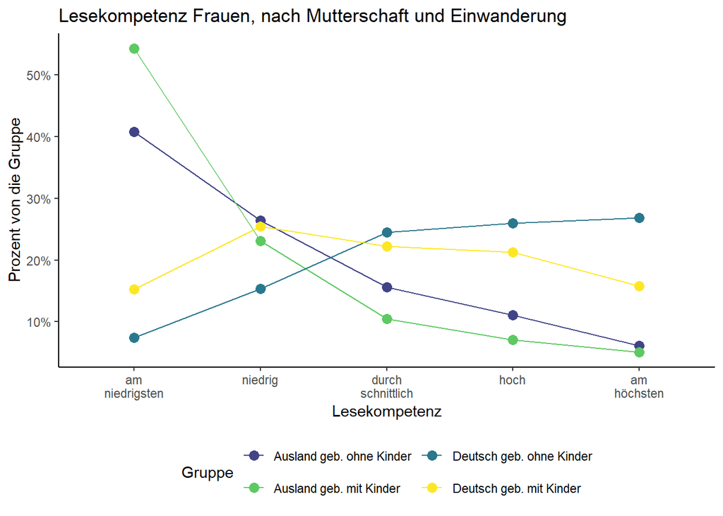

__________________________________________________________________________________________________

## 0.8 Gering lit. Zugewanderte ohne Berufsabschluss; Teilnehmende von Integrationskursen

**Grundbildungsteilzeit – Pfade in gute Arbeit (GBTZ)**

## 0.9 Nicht formal Qualifizierte mit GB-Bedarf

**GB-Pfad zur berufl. (Teil-) Qualifizierung Arbeitsloser & Beschäftigter (AoG-plus-TQ)**

## 0.10 Erwerbslose Erw. mit Migrationshintergrund

und junge Erwachsene am Übergang in die Arbeitswelt (o. Schul- /Berufsabs.)

** Mind the GAP –

GB-Pfade anschlussfähig und passgenau gestalten** __________________________________________________________________________________________________

## 0.11 Information

### 0.11.1 Zitationen

```
## [[1]]
## Wickham H, Averick M, Bryan J, Chang W, McGowan LD, François R,
## Grolemund G, Hayes A, Henry L, Hester J, Kuhn M, Pedersen TL, Miller E,
## Bache SM, Müller K, Ooms J, Robinson D, Seidel DP, Spinu V, Takahashi
## K, Vaughan D, Wilke C, Woo K, Yutani H (2019). "Welcome to the
## tidyverse." _Journal of Open Source Software_, *4*(43), 1686.
## doi:10.21105/joss.01686 <https://doi.org/10.21105/joss.01686>.
##
## [[2]]
## Wickham H, Hester J, Bryan J (2024). _readr: Read Rectangular Text
## Data_. R package version 2.1.5,
## <https://CRAN.R-project.org/package=readr>.
##
## [[3]]
## Müller K (2020). _here: A Simpler Way to Find Your Files_. R package
## version 1.0.1, <https://CRAN.R-project.org/package=here>.
##
## [[4]]
## Wickham H (2016). _ggplot2: Elegant Graphics for Data Analysis_.
## Springer-Verlag New York. ISBN 978-3-319-24277-4,
## <https://ggplot2.tidyverse.org>.
##
## [[5]]
## Zhu H (2024). _kableExtra: Construct Complex Table with 'kable' and
## Pipe Syntax_. R package version 1.4.0,
## <https://CRAN.R-project.org/package=kableExtra>.
```

### 0.11.2 Colophon